# Shootings Data Report

Khoa Tran

11/10/2019

## Summary Information

This is a summary of the mass shootings data in the US for 2018 by location ([source](http://www.shootingtracker.com)). The total number of mass shootings is 340. The total number of lives lost due to mass shootings is 373. To analyze this data, I want to define the concept of “impacted” as the total number of people killed and injured. The city that was most impacted by mass shootings is Chicago, Illinois. The state that was the most impacted by mass shootings is California. The month with the most mass shootings is June.

## Summary Table

This table shows how many people were impacted by shootings in each month, with the total impacted people sorted in descending order.

| Month | Total Affected |
| --- | --- |
| June | 257 |
| July | 226 |
| August | 173 |
| September | 163 |
| October | 156 |
| May | 151 |
| April | 115 |
| November | 112 |
| January | 110 |
| February | 105 |
| March | 78 |
| December | 74 |

#### Two Major Insights:

- The month December had the least people impacted by shootings
- The month June had the most people impacted by shootings

## Interactive Map

This map uses circles of in a variety of sizes to show the relativity how many people were impacted by shootings during the year of 2018 by location. This map also allows for visuals of area had more or less shootings.

[interactive chart not shown]

#### Two Major Insights:

- South Florida and New York had the most amount of people impacted by shootings making it dangerous regions
- The east coast has significantly more shootings than the west coast and central US

## Fifteen Worst Shootings

#### Proposed Questions:

What was the fifteen biggest mass shootings in 2018? Where were they located and how many people were impacted?

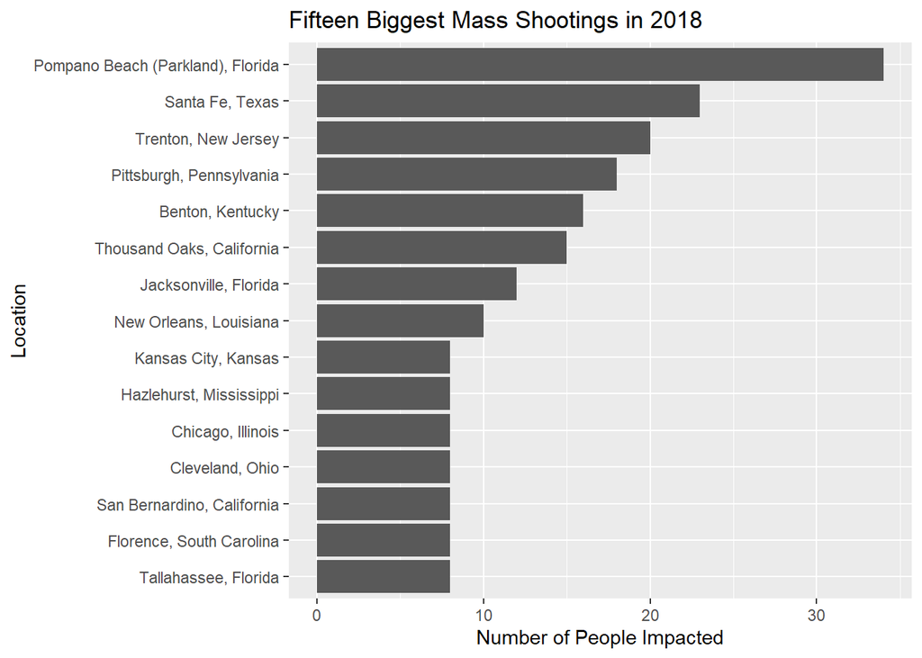

#### Two Major Insights:

- Florida and Califonira have the most number of biggest mass shootings in 2018
- Parkland, Florida was the biggest and worst shooting in 2018 with more than 30 people impacted